# Centered approximations to $v''(x)$

[AMath 586, Spring Quarter 2019](http://staff.washington.edu/rjl/classes/am586s2019/) at the University of Washington. For other notebooks, see Index.html or the [Index of all notebooks on Github](https://github.com/rjleveque/amath586s2019/blob/master/notebooks/Index.html).

This illustrates the centered difference approximation to the second derivative $v''(x)$ for a smooth function of $x$. This approximation is used for the spatial discretization of $u_{xx}(x,t)$ in solving PDEs.

```python
%pylab inline
```

Suppose we are given a function $v(x)$ that is $2\pi$-periodic, i.e. we know the values for $0 \leq x \leq 2\pi$, and we wish to approximate the derivative $v\prime(x)$ at points in this interval.

To be specific, choose $N$ equally spaced points $x_j = jh$ with equal spacing $h = 2\pi / N$, for $j=1,~2,~\ldots,~N$. Then we know the discrete function values $v_j = v(x_j)$ and want to compute approximations $w_j\approx v\prime(x_j)$ or $z_j \approx v\prime\prime(x_j)$.

## Finite differences

The centered difference approximation to $v''(x) = \frac 1 {h^2} (v(x-h) - 2v(x) + v(x+h)) + O(h^2)$ can be written as $z = A v$ (so that $z_j \approx v\prime\prime(x_j)$) with $$ A = \frac{1}{h^2} \left(\begin{array}[rrrrrr] -2&1\\ 1&-2&1\\ &1&-2&1\\ &&&\ddots\\ &&&1&-2&1\\ &&&&1&-2 \end{array}\right) $$

## Python code

We can use the `spdiags` function from `scipy.sparse` to set up a sparse matrix.

```python
from scipy.sparse import spdiags

m = 9
h = 1. / (m+1)
x = linspace(h,m*h,m)  # interior grid points
e = ones((m,1))
data = hstack([e, -2*e, e]).T
diags = [-1, 0, 1]
T = spdiags(data, diags, m, m)
A = (1./h**2) * T
```

```python
print("With m = %i, h = %6.5f" % (m,h))
print("Interior grid points: \n", x)
print("\nA = \n", h**2 * A.todense())
```

```
With m = 9, h = 0.10000
Interior grid points:
 [0.1 0.2 0.3 0.4 0.5 0.6 0.7 0.8 0.9]

A =
 [[-2.  1.  0.  0.  0.  0.  0.  0.  0.]
 [ 1. -2.  1.  0.  0.  0.  0.  0.  0.]
 [ 0.  1. -2.  1.  0.  0.  0.  0.  0.]
 [ 0.  0.  1. -2.  1.  0.  0.  0.  0.]
 [ 0.  0.  0.  1. -2.  1.  0.  0.  0.]
 [ 0.  0.  0.  0.  1. -2.  1.  0.  0.]
 [ 0.  0.  0.  0.  0.  1. -2.  1.  0.]
 [ 0.  0.  0.  0.  0.  0.  1. -2.  1.]
 [ 0.  0.  0.  0.  0.  0.  0.  1. -2.]]
```

### Test this out

Choose a function $v(x)$ with $v(0)=v(1)=0$ and work out the derivatives:

```python
v_0 = lambda x: sin(x*(x-1))
v_1 = lambda x: (2*x-1)*cos(x*(x-1))
v_2 = lambda x: -(2*x-1)**2 * sin(x*(x-1)) + 2*cos(x*(x-1))

# fine grid for plotting function and true derivative:
x_fine = linspace(0,1.,1000)
v_fine = v_0(x_fine)
z_fine = v_2(x_fine)
```

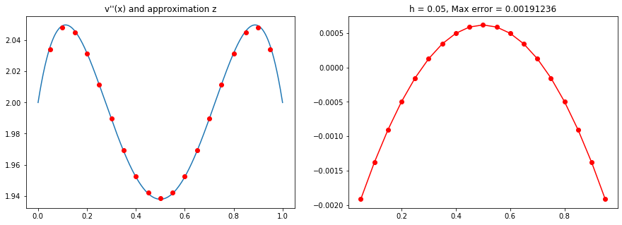

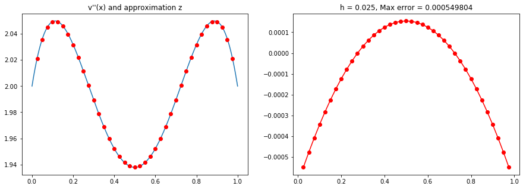

```python
def test_vxx(m):
    h = 1. / (m+1)
    x = linspace(h,m*h,m)  # interior grid points
    e = ones((m,1))
    data = hstack([e, -2*e, e]).T
    diags = [-1, 0, 1]
    T = spdiags(data, diags, m, m)
    A = (1./h**2) * T
    v = v_0(x)      # evaluate v(x_j)
    z = A.dot(v)   # sparse matrix vector product A * v

    figure(figsize=(15,5))
    subplot(121)
    plot(x_fine,v_2(x_fine))
    plot(x,z,'ro')
    title("v''(x) and approximation z")

    subplot(122)
    error = z - v_2(x)
    plot(x,error,'ro-')
    title('h = %g, Max error = %g' % (h,norm(error,inf)))

test_vxx(19)
test_vxx(39)
```

Note that reducing $h$ by a factor of 2 reduces the error by roughly a factor of 4, as expected since the approximation should be second order accurate.

If you tried this on a function that doesn't satisfy $v(0)=v(1)=0$ there would be large errors at the the boundaries unless you adjusted $Av$ to incorporate the boundary values properly.

## Periodic boundary conditions

If we assume periodic boundary conditions, the matrix is $$ A = \frac{1}{h^2} \left(\begin{array}[rrrrrr] -2&1&&&&1\\ 1&-2&1\\ &1&-2&1\\ &&&\ddots\\ &&&1&-2&1\\ 1&&&&1&-2 \end{array}\right) $$

Now the grid has to include one boundary point or the other (not both). Below we include the right boundary point.

```python
m = 9
h = 1./(m+1)
x = linspace(h,1,m+1)  # interior grid points and right boundary

e = ones((m+1,1))
data = hstack([e, e, -2*e, e, e]).T
diags = [-m, -1, 0, 1, m]
T = spdiags(data, diags, m+1, m+1)
A_periodic = (1./h**2) * T
```

For small `N` we can print the `D2` matrix without the $1/h^2$ factor so we can verify we did it right:

```python
print("With m = %i, h = %6.5f" % (m,h))
print("There are %i grid points: \n" % (m+1), x)
print("\nA_periodic = \n", h**2 * A_periodic.todense())
```

```
With m = 9, h = 0.10000
There are 10 grid points:
 [0.1 0.2 0.3 0.4 0.5 0.6 0.7 0.8 0.9 1. ]

A_periodic =
 [[-2.  1.  0.  0.  0.  0.  0.  0.  0.  1.]
 [ 1. -2.  1.  0.  0.  0.  0.  0.  0.  0.]
 [ 0.  1. -2.  1.  0.  0.  0.  0.  0.  0.]
 [ 0.  0.  1. -2.  1.  0.  0.  0.  0.  0.]
 [ 0.  0.  0.  1. -2.  1.  0.  0.  0.  0.]
 [ 0.  0.  0.  0.  1. -2.  1.  0.  0.  0.]
 [ 0.  0.  0.  0.  0.  1. -2.  1.  0.  0.]
 [ 0.  0.  0.  0.  0.  0.  1. -2.  1.  0.]
 [ 0.  0.  0.  0.  0.  0.  0.  1. -2.  1.]
 [ 1.  0.  0.  0.  0.  0.  0.  0.  1. -2.]]
```

### Test this out.

Choose a function $v(x)$ with a smooth periodic extension and compute exact derivatives:

```python
v_0 = lambda x: exp(sin(2*pi*x))
v_1 = lambda x: 2*pi*cos(2*pi*x) * v_0(x)
v_2 = lambda x: ((2*pi*cos(2*pi*x))**2 - 4*pi**2*sin(2*pi*x)) * v_0(x)

# fine grid for plotting function and true derivative:
x_fine = linspace(0,1.,1000)
v_fine = v_0(x_fine)
z_fine = v_2(x_fine)
```

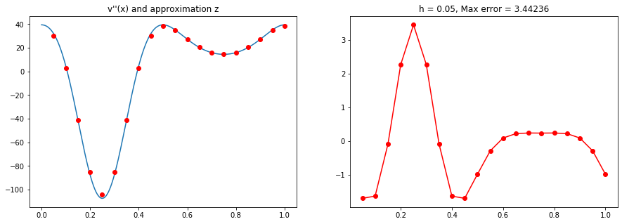

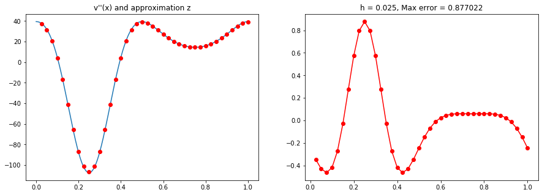

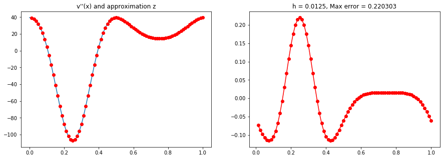

```python
def test_vxx(m):
    h = 1./(m+1)
    x = linspace(h,1,m+1)  # interior grid points and right boundary

    e = ones((m+1,1))
    data = hstack([e, e, -2*e, e, e]).T
    diags = [-m, -1, 0, 1, m]
    T = spdiags(data, diags, m+1, m+1)
    A_periodic = (1./h**2) * T

    v = v_0(x)      # evaluate v(x_j)
    z = A_periodic.dot(v)   # sparse matrix vector product A * v

    figure(figsize=(15,5))
    subplot(121)
    plot(x_fine,v_2(x_fine))
    plot(x,z,'ro')
    title("v''(x) and approximation z")

    subplot(122)
    error = z - v_2(x)
    plot(x,error,'ro-')
    title('h = %g, Max error = %g' % (h,norm(error,inf)))

test_vxx(19)
test_vxx(39)
test_vxx(79)
```

Again note that the error goes down by roughly a factor of 4 each time we double $m$.